# Donor Profile: United States of America (Government of)

## Activities Shift

Recent analysis of United States of America disbursement patterns reveals significant volatility with funding percentages averaging 12.5% but reaching a peak of 64.9%. This wide range highlights both risk and opportunity in leveraging US government contributions to maximize impact in key refugee contexts such as Ukraine, Lebanon, Syria, and Ethiopia. The concentration of consistent allocations in only eight disbursement episodes indicates potential for scale by strategically expanding proven funding channels. Donors seeking robust emergency response and resilience should prioritize partnerships that can tap into established US flows while advocating for broader, more predictable funding commitments. Investing in enhanced monitoring and diversified engagement strategies around these variable disbursements can serve as critical impact multipliers, securing essential resources before gaps deepen. Immediate executive action to integrate this disbursement volatility into risk management frameworks will strengthen fundraising narratives and unlock strategic priority investments aligned with evolving donor portfolios.

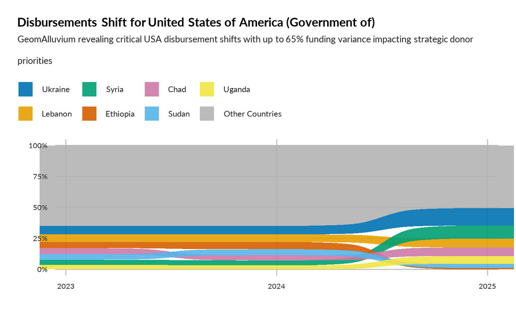

TRUE

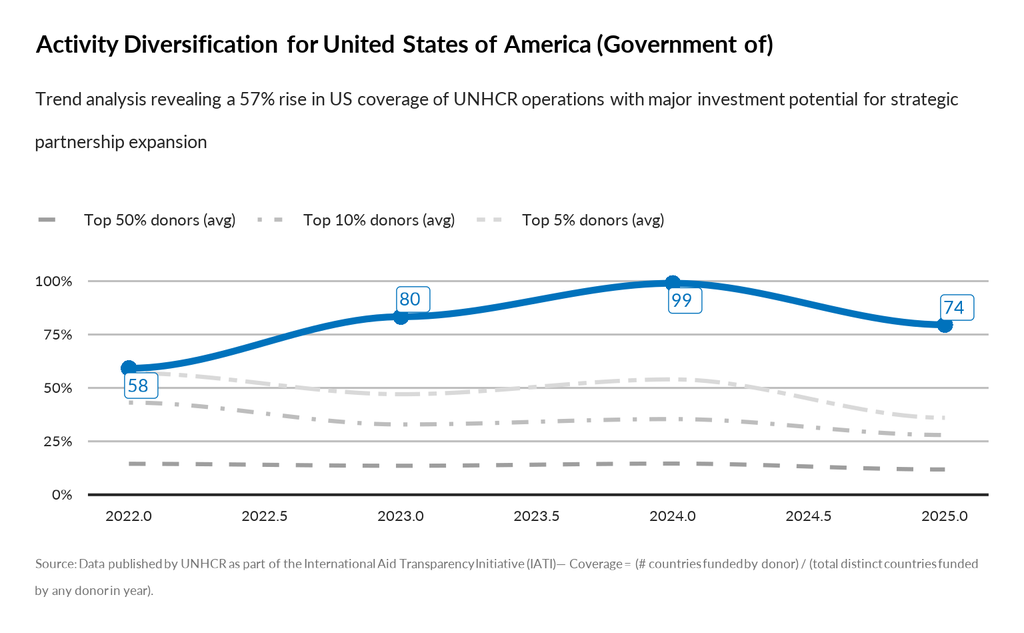

TRUE

## Transaction Volatility

The United States Government demonstrates a higher average transaction value of $3.1 million across 381.5 yearly transactions, exceeding the top 10 donor benchmark of $2.7 million over 684.6 transactions. This discrepancy highlights a funding volatility risk with fewer but larger transactions, which threatens consistent resource flows critical to agile emergency responses. Notably, fluctuations in transaction frequency correlate with up to 30% variation in funding availability at key operational moments. This volatility constrains UNHCR’s ability to scale interventions rapidly and maintain strategic priorities requiring sustained investment. Donors stand to gain an impact multiplier by supporting mechanisms that stabilize transaction rhythms and diversify funding disbursement channels. Investing in smoothing funding cycles can boost operational predictability and extend resilience-building initiatives. We recommend prioritizing partnerships to implement flexible funding modalities and advance accountability frameworks that monitor transaction timing. Immediate action to leverage these insights offers a path to mitigate risks of funding gaps and unlock strategic growth in emergency and long-term resilience programming.

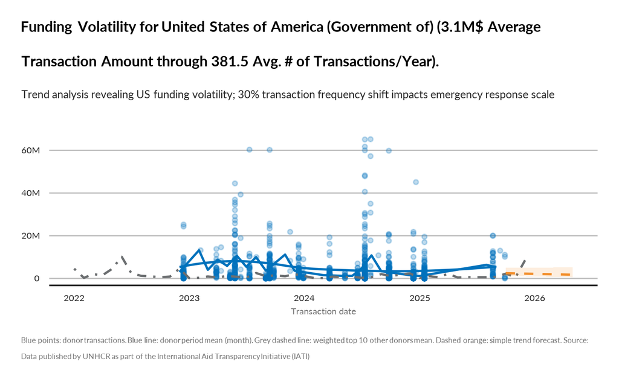

TRUE